# Bayesian Frailty models

Arnau Garcia

2024-03-27

```r
library(ggplot2)
library(dplyr)
library(rstan)
library(bayesplot)
```

We will implement in `Stan` a frailty model. We will be using the *kidney* data set, available in the `frailtyHL` library. This dataset consists of times to the first and second recurrences of infection in 38 kidney patients using a portable dialysis machine. Infections can occur at the location of insertion of the catheter. The catheter is later removed if infection occurs and can be removed for other reasons, in which case the observation is censored.

```r
library(frailtyHL)
data("kidney", package = "frailtyHL")
head(kidney)
```

```
##   id time status age sex disease frail GN AN PKD
## 1  1    8      1  28   1   Other   2.3  0  0   0
## 2  1   16      1  28   1   Other   2.3  0  0   0
## 3  2   23      1  48   2      GN   1.9  1  0   0
## 4  2   13      0  48   2      GN   1.9  1  0   0
## 5  3   22      1  32   1   Other   1.2  0  0   0
## 6  3   28      1  32   1   Other   1.2  0  0   0
```

## The frequentist model

We start fitting a frequentist frailty model:

```r
library(survival)
kidnsurv <- with(kidney, Surv(time, status))
frail_freq <- coxph(kidnsurv ~ sex + frailty(id, "gaussian"), kidney)
```

Let us see the value of the frequentist frailties:

```r
exp(frail_freq$frail)
```

```
##  [1] 1.6960604 1.4127910 1.1843046 0.5785644 1.2248612 1.0085881 2.0928489
##  [8] 0.6960889 1.0113810 0.6485790 0.8991422 1.0452731 1.4056832 0.6436286
## [15] 0.5103595 1.2170957 0.8956442 0.8680042 0.6636437 1.1198510 0.1989264
## [22] 0.6441672 1.6536939 1.0846884 1.0623733 0.7260793 1.0309991 1.6702007
## [29] 1.5591217 1.4169686 1.5949040 1.2671056 1.2740448 0.8852262 1.5562112
## [36] 0.8027952 1.1788330 0.7467219
```

We see now the regression coefficients:

```r
frail_freq$coefficients
```

```
##       sex
## -1.379586
```

Finally a summary of the model:

```r
summary(frail_freq)
```

```
## Call:
## coxph(formula = kidnsurv ~ sex + frailty(id, "gaussian"), data = kidney)
##
##   n= 76, number of events= 58
##
##                         coef  se(coef) se2    Chisq DF    p
## sex                     -1.38 0.4327   0.3144 10.16  1.00 0.0014
## frailty(id, "gaussian")                       25.01 14.16 0.0370
##
##     exp(coef) exp(-coef) lower .95 upper .95
## sex    0.2517      3.973    0.1078    0.5878
##
## Iterations: 6 outer, 38 Newton-Raphson
##      Variance of random effect= 0.5021234
## Degrees of freedom for terms=  0.5 14.2
## Concordance= 0.82  (se = 0.031 )
## Likelihood ratio test= 45.04  on 14.69 df,   p=6e-05
```

## The Bayesian model

We load the dataframe with posterior:

```r
load("posterior_frail.Rdata")
```

Let us do some nice plots:

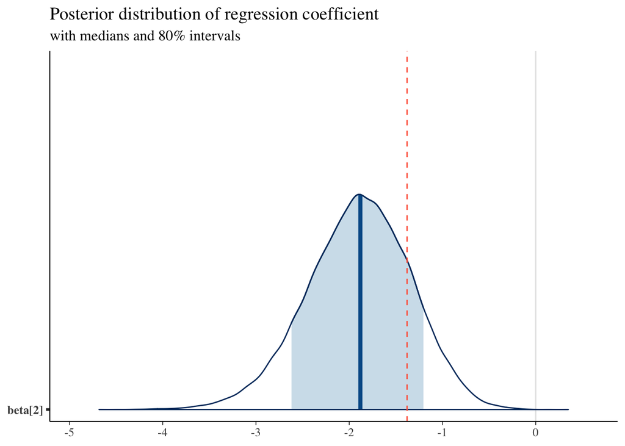

```r
plot_title <- ggtitle("Posterior distribution of regression coefficient", "with medians and 80% intervals")
mcmc_areas(posterior[2], prob = 0.8) + plot_title +
  geom_vline(xintercept =-1.379586 , color="tomato", lty=2)
```

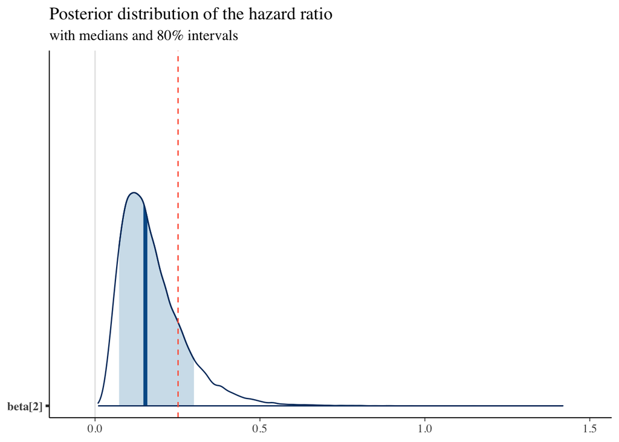

```r
plot_title <- ggtitle("Posterior distribution of the hazard ratio", "with medians and 80% intervals")
mcmc_areas(exp(posterior[2]), prob = 0.8) + plot_title +
  geom_vline(xintercept =0.2517, color="tomato", lty=2)
```

We do the same with some frailties:

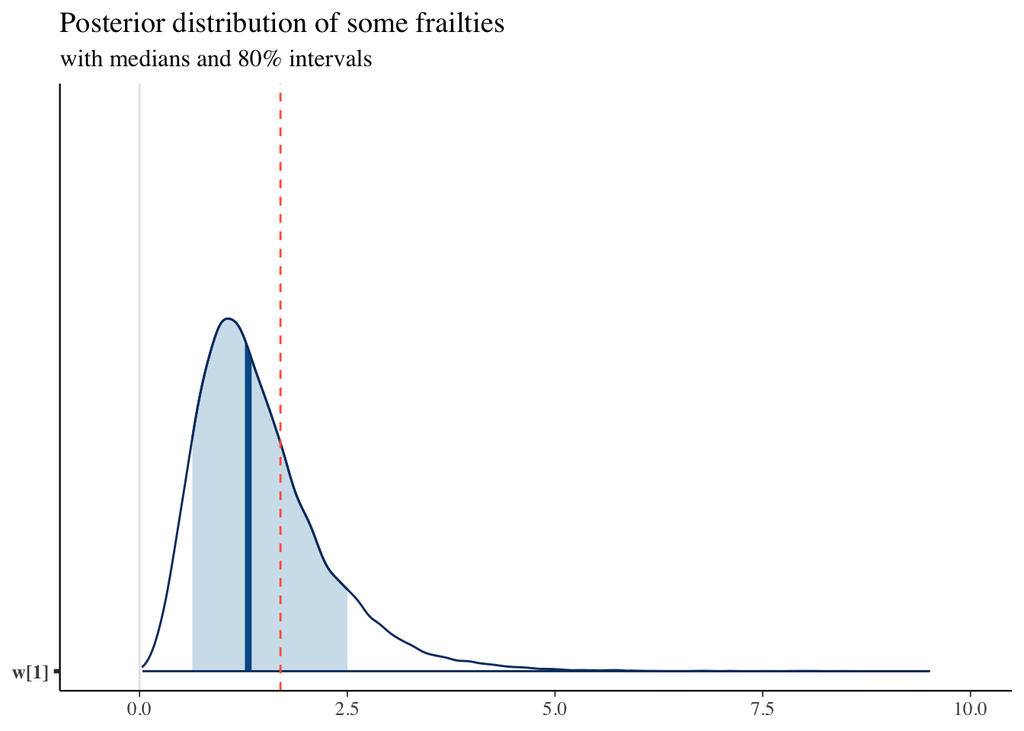

```r
plot_title <- ggtitle("Posterior distribution of some frailties", "with medians and 80% intervals")
mcmc_areas(posterior[3], prob = 0.8) + plot_title +
  geom_vline(xintercept =1.6960604 , color="tomato", lty=2)
```

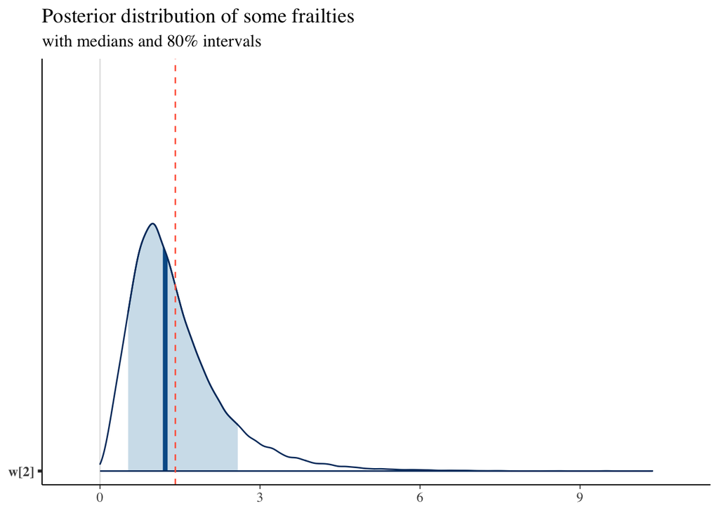

```r
plot_title <- ggtitle("Posterior distribution of some frailties", "with medians and 80% intervals")
mcmc_areas(posterior[4], prob = 0.8) + plot_title +
  geom_vline(xintercept =1.4127910 , color="tomato", lty=2)
```

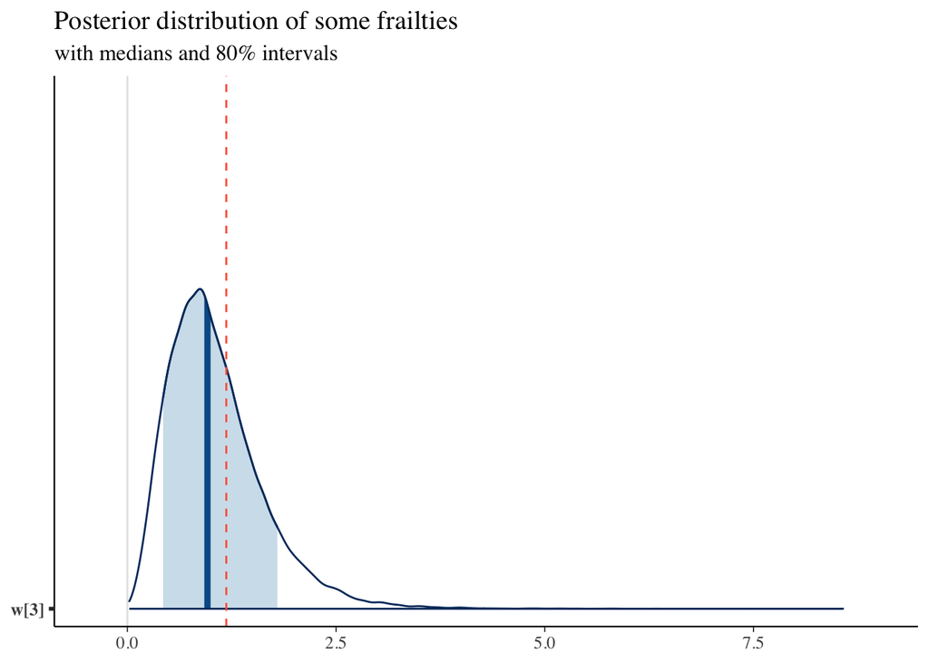

```r
plot_title <- ggtitle("Posterior distribution of some frailties", "with medians and 80% intervals")
mcmc_areas(posterior[5], prob = 0.8) + plot_title +
  geom_vline(xintercept =1.1843046 , color="tomato", lty=2)
```

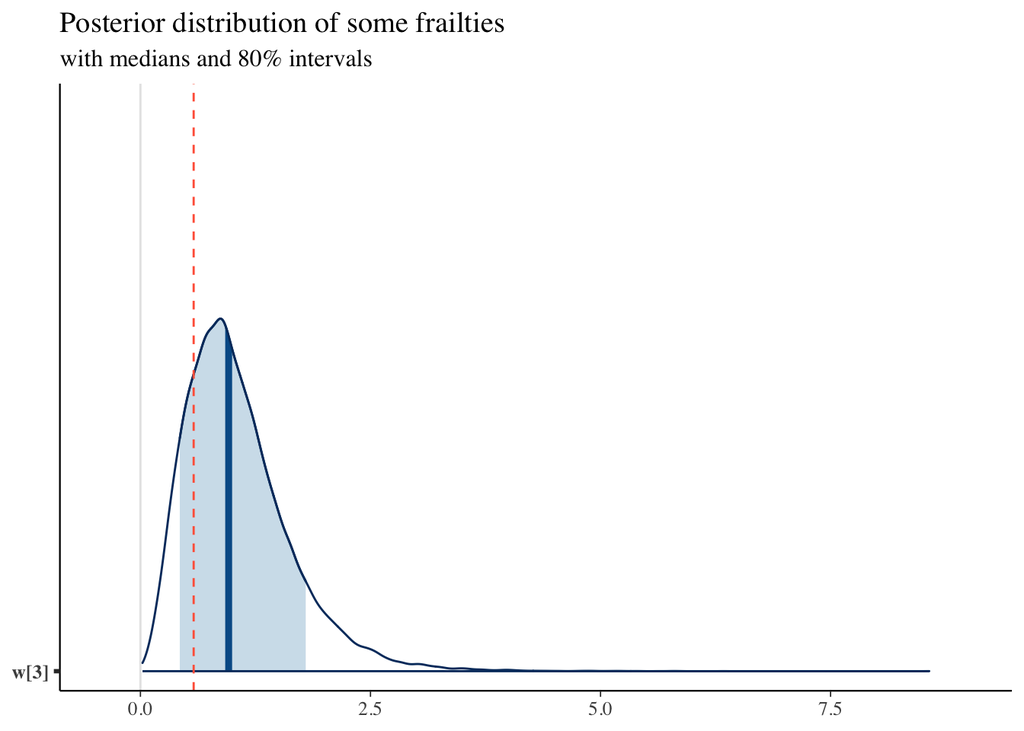

```r
plot_title <- ggtitle("Posterior distribution of some frailties", "with medians and 80% intervals")
mcmc_areas(posterior[5], prob = 0.8) + plot_title +
  geom_vline(xintercept = 0.5785644, color="tomato", lty=2)
```

We develop the plot on the paper:

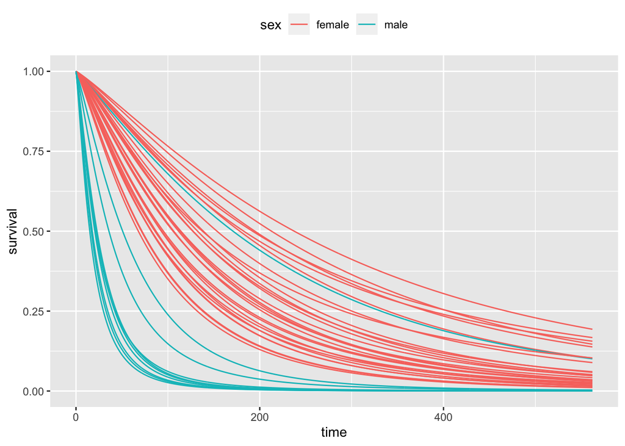

```r
grid <- 1000
n <- length(unique(kidney$id))
sex <- kidney$sex[seq(1, 2 * n, 2)] - 1 # Reference = male
time_vec <- seq(0, max(kidney$time), len = grid)
surv_vec <- matrix(NA, n, grid)
for(i in 1:n){
  for(k in 1:grid){
    surv_vec[i, k] <- mean(exp(-posterior[,2+i] * posterior[, c("lambda")] * exp(posterior[,2] * sex[i]) * time_vec[k]^posterior[,c("alpha")]))
  }
}
sex.col <- sex
sex.col[sex == 0] <- "male"
sex.col[sex == 1] <- "female"
df <- data.frame(time = rep(time_vec, n), survival = c(t(surv_vec)),
                 patient = rep(1:n, each = grid), sex = rep(sex.col, each = grid))
ggplot(data = df, aes(x = time, y = survival, group = patient, colour = sex)) +
  geom_line() + theme(legend.position = "top")
```

We compute several summary statistics:

```r
quantile(posterior[,c("beta[1]")] , probs = c(0.025, 0.50, 0.975))
```

```
##      2.5%       50%     97.5%
## -5.351848 -4.093657 -3.021648
```

```r
quantile(posterior[,c("beta[2]")] , probs = c(0.025, 0.50, 0.975))
```

```
##       2.5%        50%      97.5%
## -3.0524523 -1.8802965 -0.8670458
```

```r
quantile(posterior[,c("alpha")] , probs = c(0.025, 0.50, 0.975))
```

```
##      2.5%       50%     97.5%
## 0.9288677 1.2230752 1.5709678
```

```r
quantile(posterior[,c("psi")] , probs = c(0.025, 0.50, 0.975))
```

```
##     2.5%      50%    97.5%
## 0.791507 1.885014 8.542626
```

```r
quantile(posterior[,c("lambda")] , probs = c(0.025, 0.50, 0.975))
```

```
##        2.5%         50%       97.5%
## 0.004739385 0.016678131 0.048720844
```

```r
sd(posterior[,c("beta[1]")])
```

```
## [1] 0.5938078
```

```r
sd(posterior[,c("beta[2]")])
```

```
## [1] 0.5566226
```

```r
sd(posterior[,c("alpha")])
```

```
## [1] 0.1632803
```

```r
sd(posterior[,c("psi")])
```

```
## [1] 5.86262
```

```r
sd(posterior[,c("lambda")])
```

```
## [1] 0.01168442
```

The Kendall tau on the within-cluster association:

```r
plot_title <- ggtitle("Posterior distribution Kendall's tau", "with medians and 80% intervals")
p<-mcmc_areas(1/(1+2*posterior["psi"]), prob = 0.8) + plot_title
```

Summary of the Kendall’s tau:

```r
summary(1/(1+2*posterior["psi"]))
```

```
##       psi
##  Min.   :0.001773
##  1st Qu.:0.152949
##  Median :0.209642
##  Mean   :0.212813
##  3rd Qu.:0.269009
##  Max.   :0.584376
```

```r
library(knitr)
library(kableExtra)
d <- head(kidney)
table <- kable(d)
save_kable(table, file = "table.pdf")
```

```
## PhantomJS not found. You can install it with webshot::install_phantomjs(). If it is installed, please make sure the phantomjs executable can be found via the PATH variable.
```

```
## save_kable could not create image with webshot package. Please check for any webshot messages
```

We try to see the “predictive” at the second level of our hierarchical model:

```r
frail_pred_scd_lev <- rgamma(n=40000, shape = posterior$psi, rate = posterior$psi)
```

Let us plot these values:

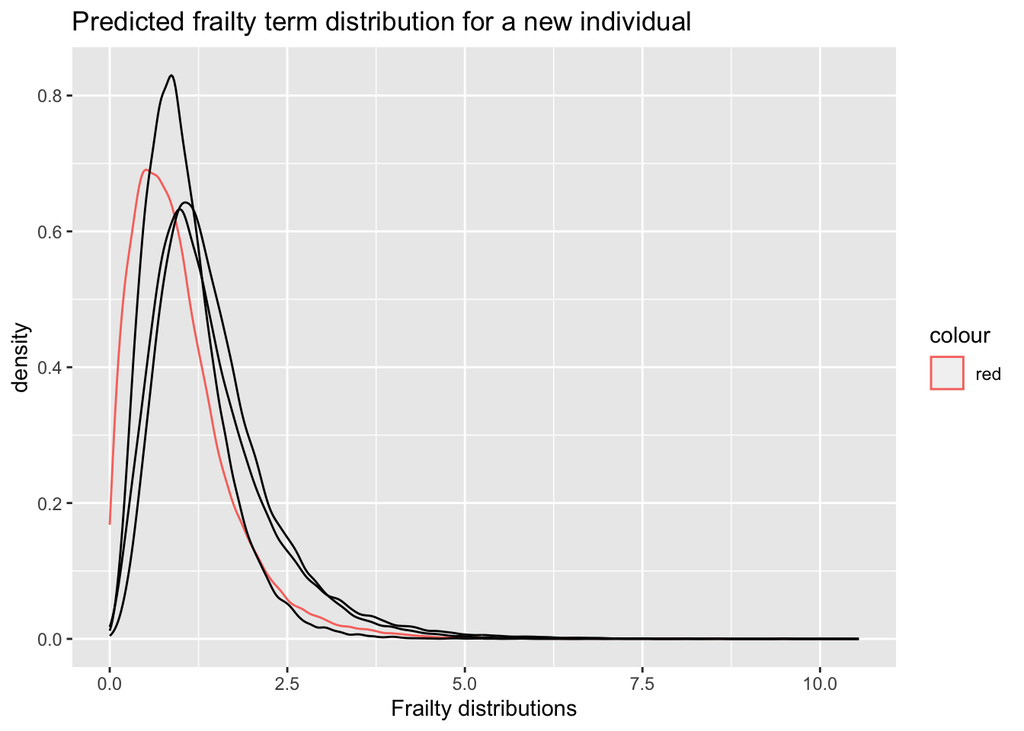

```r
title<- ggtitle("Predicted frailty term distribution for a new individual")
ggplot()+
  geom_density(aes(x=frail_pred_scd_lev, color="red"))+
  geom_density(aes(x=posterior$`w[1]`))+
  geom_density(aes(x=posterior$`w[2]`))+
  geom_density(aes(x=posterior$`w[3]`))+
  title + xlab("Frailty distributions")
```

```r
mean(frail_pred_scd_lev)
```

```
## [1] 0.9983688
```